# FbHresExpDH

## Explant PerivFb 1

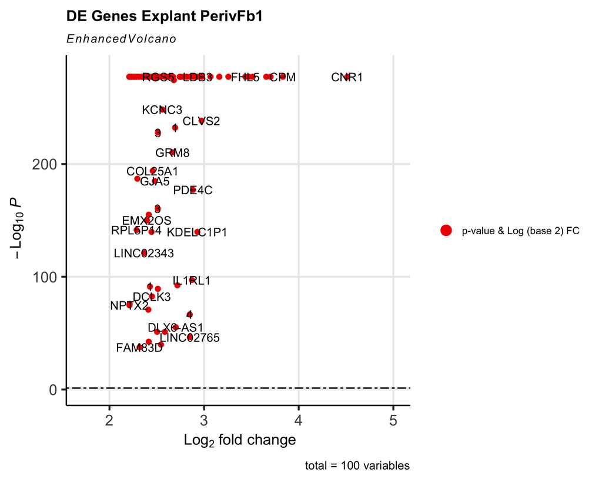

```r
# Compare Fb1 explant to all clusters
markerG <- markerGenesAllFbExpDH_clusterCond %>%
  filter(cluster %in% "explant_PerivFb1") %>%
  filter(avg_log2FC > 0.5) %>%
  filter(p_val_adj < 0.05)%>%
  top_n(100, wt = abs(avg_log2FC))%>%
  mutate(Gene = sub("^.*\\.", "", gene), EnsID = sub("\\..*", "", gene))

#Plot volanco plot
EnhancedVolcano(markerG,
                x = 'avg_log2FC',
                y = 'p_val_adj',
                lab = markerG$Gene,
                xlim = c(min(markerG$avg_log2FC) - 0.5, max(markerG$avg_log2FC) + 0.5),
                title = 'DE Genes Explant PerivFb1',
                xlab = bquote(~Log[2]~ 'fold change'),
                pCutoff = 0.05,
                FCcutoff = 1,
    cutoffLineType = 'twodash',
    cutoffLineWidth = 0.8,
    pointSize = 2.0,
    labSize = 5.0,
    # shape = c(1,4, 23,25),
    colAlpha = 1,
    legendLabels=c('Not sig.','Log (base 2) FC','p-value',
      'p-value & Log (base 2) FC'),
    legendPosition = 'right',
    legendLabSize = 12,
    gridlines.minor = FALSE)
```

### Upregulated Explant PerivFb1

EGFLAM (EGF Like, Fibronectin Type III And Laminin G Domains) - Predicted to enable calcium ion binding activity and glycosaminoglycan binding activity. Predicted to act upstream of or within extracellular matrix organization and positive regulation of cell-substrate adhesion. Part of cell surface. CD36 - fourth major glycoprotein of the platelet surface and serves as a receptor for thrombospondin in platelets and various cell lines. Since thrombospondins are widely distributed proteins involved in a variety of adhesive processes, this protein may have important functions as a cell adhesion molecule. It binds to collagen, thrombospondin, anionic phospholipids and oxidized LDL. FLT1 (Fms Related Receptor Tyrosine Kinase 1) - encodes a member of the vascular endothelial growth factor receptor (VEGFR) family. Protein binds to VEGFR-A, VEGFR-B and placental growth factor and plays an important role in angiogenesis and vasculogenesis. Expression of this receptor is found in vascular endothelial cells, placental trophoblast cells and peripheral blood monocytes. FHL5 (Four And A Half LIM Domains 5) - May be involved in the regulation of spermatogenesis. CPM (Carboxypeptidase M) - membrane-bound arginine/lysine carboxypeptidase. Its expression is associated with monocyte to macrophage differentiation.  
CNR1 (Cannabinoid Receptor 1) - receptors have been found to be involved in the cannabinoid-induced CNS effects.  
GPR63 (G Protein-Coupled Receptor 63) - Predicted to be involved in G protein-coupled receptor signaling pathway. Located in cytosol; nucleoplasm; and plasma membrane. KCNC3 (Potassium Voltage-Gated Channel Subfamily C Member 3) - protein encoded by this gene belongs to the delayed rectifier class of channel proteins and is an integral membrane protein that mediates the voltage-dependent potassium ion permeability of excitable membranes. CLVS2 (Clavesin 2)- Required for normal morphology of late endosomes and/or lysosomes in neurons (By similarity). GRM8 (Glutamate Metabotropic Receptor 8) -Glutamatergic neurotransmission is involved in most aspects of normal brain function and can be perturbed in many neuropathologic conditions. Linked to the inhibition of the cyclic AMP cascade but differ in their agonist selectivities. PDE4C (Phosphodiesterase 4C) - PDE hydrolyzes the second messenger, cAMP, which is a regulator and mediator of a number of cellular responses to extracellular signals. Thus, by regulating the cellular concentration of cAMP, this protein plays a key role in many important physiological processes. CDH8 (Cadherin 8) - Integral membrane proteins that mediate calcium-dependent cell-cell adhesion. This particular cadherin is expressed in brain and is putatively involved in synaptic adhesion, axon outgrowth and guidance. EMX2OS (EMX2 Opposite Strand/Antisense RNA) - affiliated with the lncRNA class. KDELC1P1 - Pseudogene. LINC02343 - Long Intergenic Non-Protein Coding RNA 2343. DCLK3 (Doublecortin Like Kinase 3) - Predicted to enable protein serine/threonine kinase activity. Predicted to be involved in protein localization to nucleus. Predicted to act upstream of or within peptidyl-serine phosphorylation. Predicted to be active in cytoplasm and nucleus. TFCP2L1 (Transcription Factor CP2 Like 1) - Enables RNA polymerase II cis-regulatory region sequence-specific DNA binding activity. Involved in regulation of transcription by RNA polymerase II. Predicted to be located in chromatin. BCAN (Brevican) - encodes a member of the lectican family of chondroitin sulfate proteoglycans that is specifically expressed in the central nervous system. This protein is developmentally regulated and may function in the formation of the brain extracellular matrix. This protein is highly expressed in gliomas.

## Donoheart PerivFb2

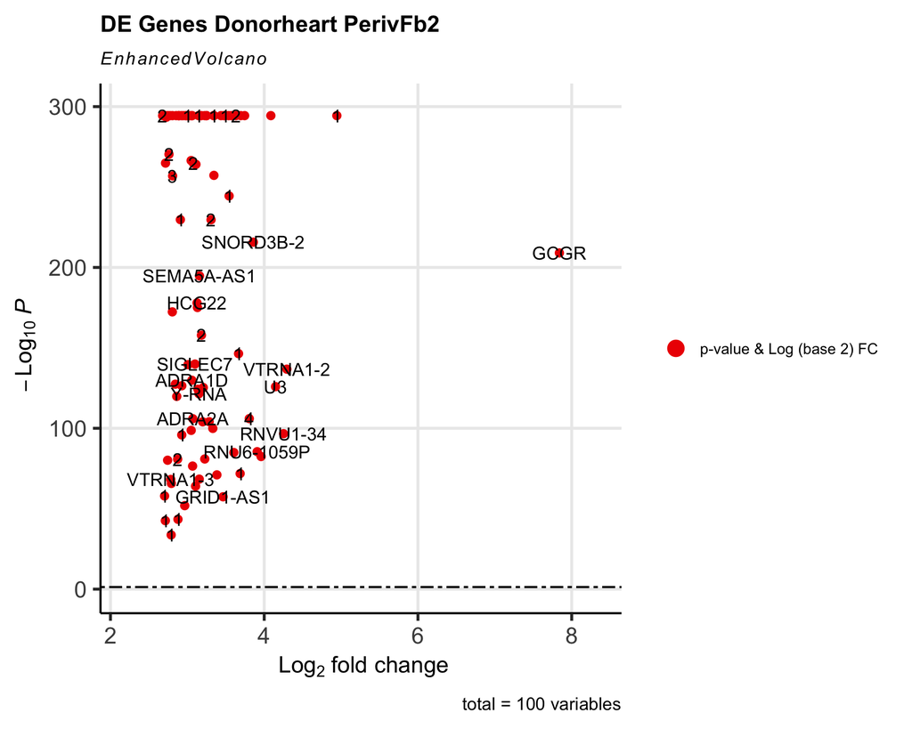

```r
# Compare Fb1 explant to all clusters
markerG <- markerGenesAllFbExpDH_clusterCond %>%
  filter(cluster %in% "donorheart_PerivFb2") %>%
  filter(avg_log2FC > 0.5) %>%
  filter(p_val_adj < 0.05)%>%
  top_n(100, wt = abs(avg_log2FC))%>%
  mutate(Gene = sub("^.*\\.", "", gene), EnsID = sub("\\..*", "", gene))

#Plot volanco plot
EnhancedVolcano(markerG,
                x = 'avg_log2FC',
                y = 'p_val_adj',
                lab = markerG$Gene,
                xlim = c(min(markerG$avg_log2FC) - 0.5, max(markerG$avg_log2FC) + 0.5),
                title = 'DE Genes Donorheart PerivFb2',
                xlab = bquote(~Log[2]~ 'fold change'),
                pCutoff = 0.05,
                FCcutoff = 1,
    cutoffLineType = 'twodash',
    cutoffLineWidth = 0.8,
    pointSize = 2.0,
    labSize = 5.0,
    # shape = c(1,4, 23,25),
    colAlpha = 1,
    legendLabels=c('Not sig.','Log (base 2) FC','p-value',
      'p-value & Log (base 2) FC'),
    legendPosition = 'right',
    legendLabSize = 12,
    gridlines.minor = FALSE)
```

### Upregulated Donorheart PerivFb2 DAB1-AS1 (DAB1 Antisense RNA 1) - affiliated with the lncRNA class.  
SNORD3B-2 (Small Nucleolar RNA, C/D Box 3B-2) - Predicted to be involved in RNA processing. Predicted to be located in nucleolus. GCGR (Glucagon Receptor) - important in controlling blood glucose levels.  
SEMA5A-AS1 (SEMA5A Antisense RNA 1) - affiliated with the lncRNA class.  
HCG22 (HLA Complex Group 22) - affiliated with the lncRNA class. SIGLEC7 (Sialic Acid Binding Ig Like Lectin 7) - Predicted to enable sialic acid binding activity. Predicted to be involved in cell adhesion. Predicted to be located in membrane. Predicted to be active in plasma membrane.  
VTRNA1-2 (Vault RNA 1-2) - affiliated with the lncRNA class.  
HMGB1P27 - High Mobility Group Box 1 Pseudogene 27.  
ADARB2-AS1 (ADARB2 Antisense RNA 1) - affiliated with the lncRNA class. EGFLAM-AS2 (EGFLAM Antisense RNA 2) - affiliated with the lncRNA class. LINC01541 - Long Intergenic Non-Protein Coding RNA 1541. RPL35AP31 - Ribosomal Protein L35a Pseudogene 31.  
GRID1-AS1 (GRID1 Antisense RNA 1) - affiliated with the lncRNA class.

# Compare explant clusters vs donorheart clusters

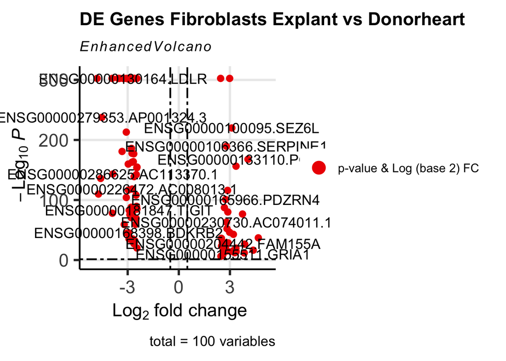

```r
#Compare dominant fibroblasts between donorheart and explant
Seurat::Idents(seuratAllFbExpDH) <- "diseaseCond_clusterName"
markersdomFbExpDH <- Seurat::FindMarkers(seuratAllFbExpDH,
                       ident.1 = c("explant_Fb1", "explant_Fb2"),
                       ident.2 = c("donorheart_Fb3", "donorheart_Fb4"),
                       test.use ="wilcox")

#The result of FindMarkers() is a data frame with gene names as row names, not in a gene column
markersdomFbExpDH$gene <- rownames(markersdomFbExpDH)

#Save table
write.table(markersdomFbExpDH,
            file= "/Users/immbio/Desktop/HumanHeartCarTrans2/analysis/markersdomFbExpDH",
            sep="\t",
            quote=F,
            row.names=F,
            col.names=T)

#Filter for topgenes
top_genesdomFbExpDH <- markersdomFbExpDH %>%
  filter(p_val_adj < 0.05) %>%
  top_n(100, wt = abs(avg_log2FC))

top_genesdomFbExpDH <- top_genesdomFbExpDH %>%
  mutate(Gene=gene) %>%
  mutate(gene=gsub("^.*\\.", "", Gene))  %>%
  mutate(EnsID=gsub("\\..*","", Gene))


# Prep for input
top_genesdomFbExpDH <- as.data.frame(top_genesdomFbExpDH)


#Plot volanco plot
EnhancedVolcano(top_genesdomFbExpDH,
                x = 'avg_log2FC',
                y = 'p_val_adj',
                lab = top_genesdomFbExpDH$Gene,
                xlim = c(min(top_genesdomFbExpDH$avg_log2FC) - 0.5, max(top_genesdomFbExpDH$avg_log2FC) + 0.5),
                title = 'DE Genes Fibroblasts Explant vs Donorheart',
                xlab = bquote(~Log[2]~ 'fold change'),
                pCutoff = 0.05,
                FCcutoff = 0.5,
    cutoffLineType = 'twodash',
    cutoffLineWidth = 0.8,
    pointSize = 2.0,
    labSize = 5.0,
    # shape = c(1,4, 23,25),
    colAlpha = 1,
    legendLabels=c('Not sig.','Log (base 2) FC','p-value',
      'p-value & Log (base 2) FC'),
    legendPosition = 'right',
    legendLabSize = 12,
    gridlines.minor = FALSE)
```

### Upregulated epxlanted fibroblasts: PDK 4 (Pyruvate Dehydrogenase Kinase 4) - encodes a mitochondrial protein with a histidine kinase domain. This protein is located in the matrix of the mitrochondria and inhibits the pyruvate dehydrogenase complex by phosphorylating one of its subunits, thereby contributing to the regulation of glucose metabolism. Expression of this gene is regulated by glucocorticoids, retinoic acid and insulin.  
SEZ6L (Seizure related 6 homolog like) - predicted to be involved in synapse maturation, located in endoplasmc reticulum membrane. RGCC - thought to regulate cell cycle progression. It is induced by p53 in response to DNA damage, or by sublytic levels of complement system proteins that result in activation of the cell cycle. SLC10A6 (Solute Carrier Family 10 Member 6) - Predicted to enable bile acid:sodium symporter activity. Predicted to be involved in bile acid and bile salt transport. Predicted to be located in plasma membrane. LINC01239 (Long Intergenic Non-Protein Coding RNA 1239) LGR5 (Leucine Rich Repeat Containing G Protein-Coupled Receptor 5) - receptor for R-spondins and is involved in the canonical Wnt signaling pathway. This protein plays a role in the formation and maintenance of adult intestinal stem cells during postembryonic development.

### Downregulated:

LDLR (low density Lipoprotein receptor) - encoded protein is normally bound at the cell membrane, where it binds low density lipoprotein/cholesterol and is taken into the cell.  
FGF7 (Fibroblast Growth Factor 7) - NPPC - FGF family members possess broad mitogenic and cell survival activities, and are involved in a variety of biological processes, including embryonic development, cell growth, morphogenesis, tissue repair, tumor growth and invasion. CDKN3 (Cyclin Dependent Kinase Inhibitor 3) - identified as a cyclin-dependent kinase inhibitor, and has been shown to interact with, and dephosphorylate CDK2 kinase, thus prevent the activation of CDK2 kinase. This gene was reported to be deleted, mutated, or overexpressed in several kinds of cancers.  
POU2F3 (POU Class 2 Homeobox 3) - POU domain transcription factors bind to a specific octamer DNA motif and regulate cell type-specific differentiation pathways. The encoded protein is primarily expressed in the epidermis, and plays a critical role in keratinocyte proliferation and differentiation.  
SCD (Stearoyl-CoA Desaturase) - encodes an enzyme involved in fatty acid biosynthesis, primarily the synthesis of oleic acid. The protein belongs to the fatty acid desaturase family and is an integral membrane protein located in the endoplasmic reticulum. CXCL1 LGALS2 (Galectin 2) - soluble beta-galactoside binding lectin.  
SLC9A9-AS1 (SLC9A9 Antisense RNA1) - affiliated with the lncRNA class SNORD3B-2 - Predicted to be involved in RNA processing. Predicted to be located in nucleolus. SMLR1 (small leucine rich protein 1) - predicted to be located in the membrane LIF (LIF Interleukin 6 Family Cytokine) - pleiotropic cytokine; induction of hematopoietic differentiation in normal and myeloid leukemia cells, induction of neuronal cell differentiation, regulator of mesenchymal to epithelial conversion during kidney development, may also have a role in immune tolerance at the maternal-fetal interface. TIGIT - expressed on several classes of T cells including follicular B helper T cells (TFH).

# Compare Fb explant vs Fb donoheart

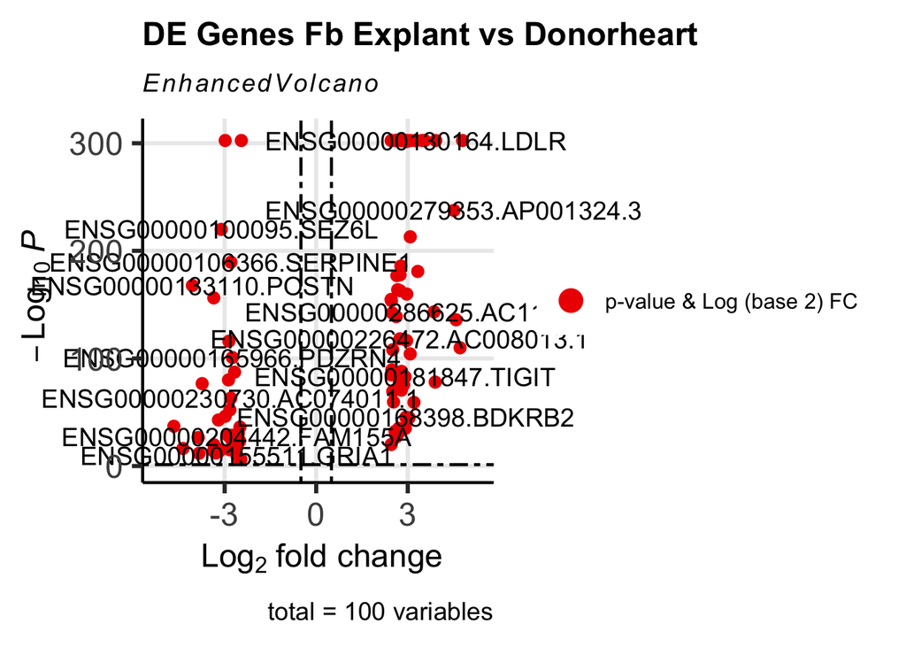

# New upregulated in donorheart CCL2

# New downregulated in donorheart

SERPINE1 (Serpin Family E Member 1) - principal inhibitor of tissue plasminogen activator (tPA) and urokinase (uPA), and hence is an inhibitor of fibrinolysis.  
POSTN (Periostin) - secreted extracellular matrix protein that functions in tissue development and regeneration, including wound healing, and ventricular remodeling following myocardial infarction. The encoded protein binds to integrins to support adhesion and migration of epithelial cells. PDZRN4 (PDZ Domain Containing Ring Finger 4) - Predicted to enable zinc ion binding activity.

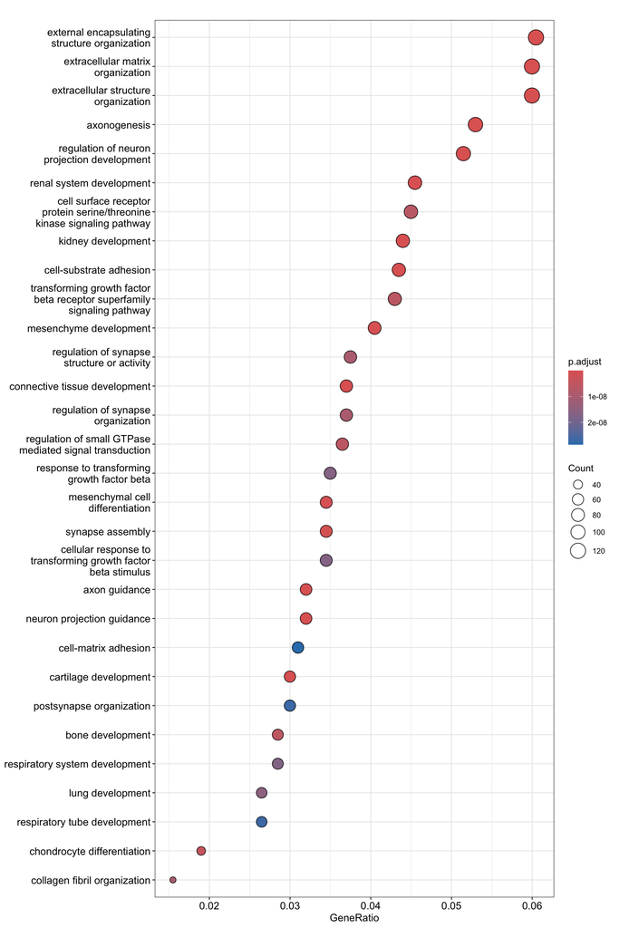

```r
#markerGenesAllFbExpDH_clusterCond <- read.delim("~/Desktop/HumanHeartCarTrans2/analysis/markerGenesAllFbExpDH_clusterCond", header = TRUE, sep = "\t")

## adjust table
markerG <- markerGenesAllFbExpDH_clusterCond %>%
  filter(avg_log2FC > 0.5) %>%
  filter(cluster %in% c("explant_Fb1", "explant_Fb2")) %>%
  mutate(Gene = sub("^.*\\.", "", gene), EnsID = sub("\\..*", "", gene))

## GSEA
ego <- enrichGO(gene = unique(markerG$EnsID),
                          OrgDb = "org.Hs.eg.db",
                          keyType = 'ENSEMBL',
                          ont = "BP",
                          pAdjustMethod = "BH",
                          pvalueCutoff = 0.05,
                          qvalueCutoff = 0.05)
ego <- setReadable(ego, OrgDb = org.Hs.eg.db)
dotplot(ego, showCategory=30)
```

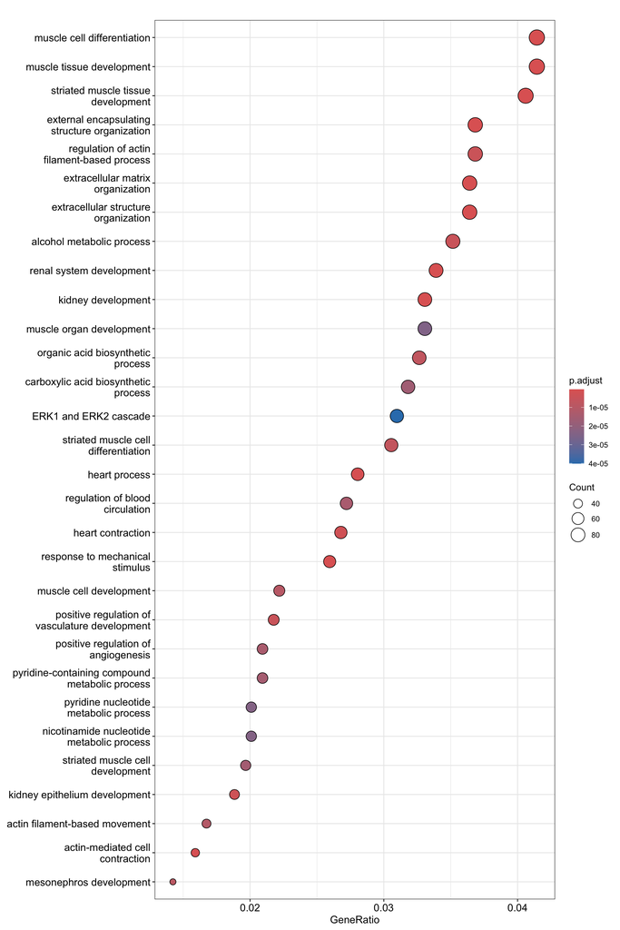

```r
## adjust table
markerG <- markerGenesAllFbExpDH_clusterCond %>%
  filter(avg_log2FC > 0.5) %>%
  filter(cluster %in% c("donorheart_Fb3", "donorheart_Fb4")) %>%
  mutate(Gene = sub("^.*\\.", "", gene),
         EnsID = sub("\\..*", "", gene))

## GSEA
ego <- enrichGO(gene = unique(markerG$EnsID),
                          OrgDb = "org.Hs.eg.db",
                          keyType = 'ENSEMBL',
                          ont = "BP",
                          pAdjustMethod = "BH",
                          pvalueCutoff = 0.05,
                          qvalueCutoff = 0.05)
ego <- setReadable(ego, OrgDb = org.Hs.eg.db)
dotplot(ego, showCategory=30)
```

# Compare PerivFb explant vs donorheart

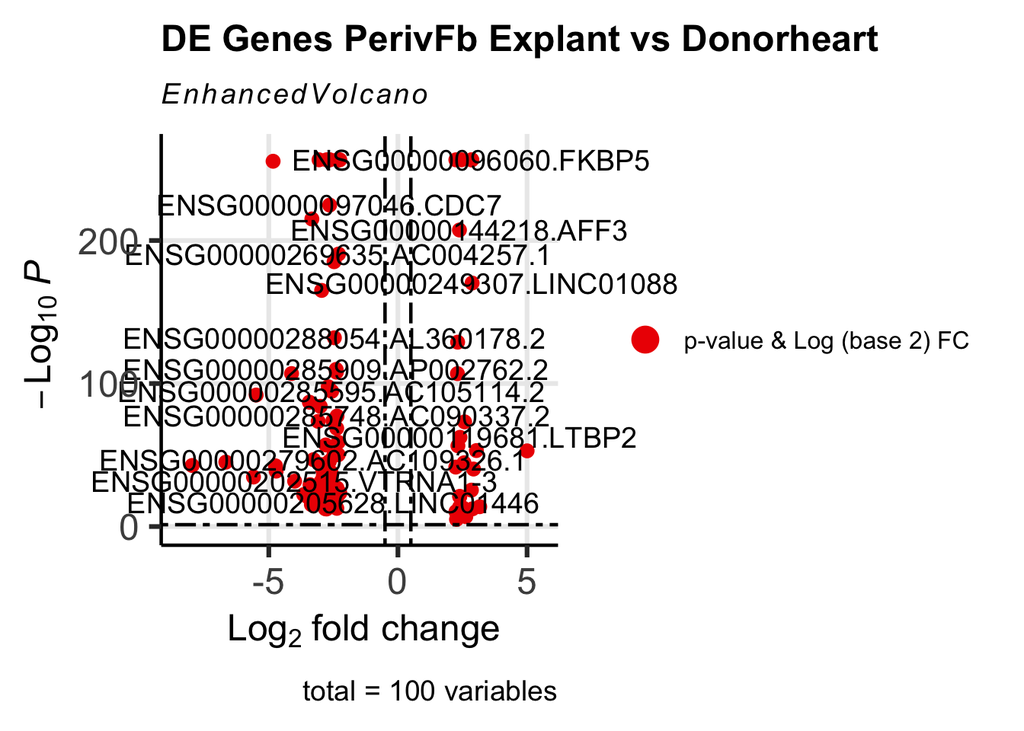

### Upregulated Explant: FKBP5 (FKBP Prolyl Isomerase 5) - member of the immunophilin protein family, which play a role in immunoregulation and basic cellular processes involving protein folding and trafficking. It is thought to mediate calcineurin inhibition.  
AFF3 (ALF Transcription Elongation Factor 3) - encodes a tissue-restricted nuclear transcriptional activator that is preferentially expressed in lymphoid tissue. LINC01088 - Long Intergenic Non-Protein Coding RNA 1088.  
RGS6 (Regulator Of G Protein Signaling 6) - RGS proteins negatively regulate G protein signaling, and may modulate neuronal, cardiovascular, lymphocytic activities, and cancer risk. Many alternatively spliced transcript variants encoding different isoforms.  
COL25A1 (Collagen Type XXV Alpha 1 Chain) - brain-specific membrane associated collagen. CLAC inhibits rather than facilitates amyloid fibril elongation. LTBP2 (Latent Transforming Growth Factor Beta Binding Protein 2) - latent transforming growth factor (TGF)-beta binding proteins (LTBP), this protein possesses unique regions and with most similarity to the fibrillins. May have multiple functions: as a member of the TGF-beta latent complex, as a structural component of microfibrils, and a role in cell adhesion. NOX4 (NADPH Oxidase 4) - encodes a member of the NOX-family of enzymes that functions as the catalytic subunit the NADPH oxidase complex. Localized to non-phagocytic cells where it acts as an oxygen sensor and catalyzes the reduction of molecular oxygen to various reactive oxygen species (ROS). NPPB - Natriuretic Peptide B.  
BMS1P10 - BMS1 Pseudogene 10.  
CBLN1 (Cerebellin 1 Precursor) - encodes a cerebellum-specific precursor protein, precerebellin, with similarity to the globular (non-collagen-like) domain of complement component C1qB. Gives rise to several derivatives, including the hexadecapeptide, cerebellin, which is highly enriched in postsynaptic structures of Purkinje cells. FOSB (FosB Proto-Oncogene, AP-1 Transcription Factor Subunit) - can dimerize with proteins of the JUN family, thereby forming the transcription factor complex AP-1. As such, the FOS proteins have been implicated as regulators of cell proliferation, differentiation, and transformation. 7SK - RN7SK? Predicted to be involved in negative regulation of transcription elongation by RNA polymerase II.

### Downregulated Explant:

LINC00486 - Long Intergenic Non-Protein Coding RNA 486.  
CCL2 CDC7 (Cell Division Cycle 7) -cell division cycle protein with kinase activity that is critical for the G1/S transition.  
BHLHE40 (Basic Helix-Loop-Helix Family Member E40) - expressed in various tissues. Can interact with ARNTL or compete for E-box binding sites in the promoter of PER1 and repress CLOCK/ARNTL’s transactivation of PER1. This gene is believed to be involved in the control of circadian rhythm and cell differentiation.  
TEX14 (Testis Expressed 14, Intercellular Bridge Forming Factor) - necessary for intercellular bridges in germ cells, which are required for spermatogenesis.  
BCL3 (BCL3 Transcription Coactivator) - proto-oncogene candidate in some cases of B-cell leukemia. SNORD3B-2 (Small Nucleolar RNA, C/D Box 3B-2) - Predicted to be involved in RNA processing. Predicted to be located in nucleolus.  
NTNG1 (Netrin G1) - preproprotein that is processed into a secreted protein containing eukaroytic growth factor (EGF)-like domains. This protein acts to guide axon growth during neuronal development. SNORD3B-1 (Small Nucleolar RNA, C/D Box 3B-1) - Predicted to be involved in RNA processing. Predicted to be located in nucleolus. MROH5 - Maestro Heat Like Repeat Family Member 5 (Gene/Pseudogene).  
POU2F3 (POU Class 2 Homeobox 3) - POU domain transcription factors bind to a specific octamer DNA motif and regulate cell type-specific differentiation pathways. The encoded protein is primarily expressed in the epidermis, and plays a critical role in keratinocyte proliferation and differentiation. PRB1 (Proline Rich Protein BstNI Subfamily 1) - Predicted to be located in extracellular region. RN7SL706P - Pseudogene.

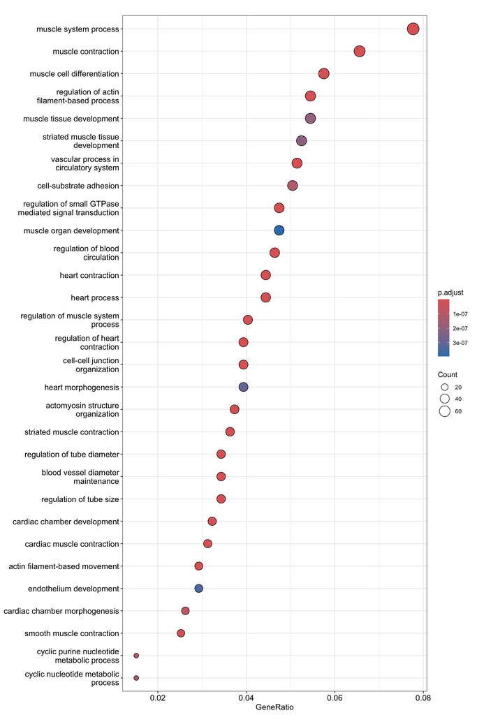

```r
#markerGenesAllFbExpDH_clusterCond <- read.delim("~/Desktop/HumanHeartCarTrans2/analysis/markerGenesAllFbExpDH_clusterCond", header = TRUE, sep = "\t")

## adjust table
markerG <- markerGenesAllFbExpDH_clusterCond %>%
  filter(avg_log2FC > 0.5) %>%
  filter(cluster %in% c("explant_PerivFb1")) %>%
  mutate(Gene = sub("^.*\\.", "", gene),
         EnsID = sub("\\..*", "", gene))

## GSEA
ego <- enrichGO(gene = unique(markerG$EnsID),
                          OrgDb = "org.Hs.eg.db",
                          keyType = 'ENSEMBL',
                          ont = "BP",
                          pAdjustMethod = "BH",
                          pvalueCutoff = 0.05,
                          qvalueCutoff = 0.05)
ego <- setReadable(ego, OrgDb = org.Hs.eg.db)
dotplot(ego, showCategory=30)
```

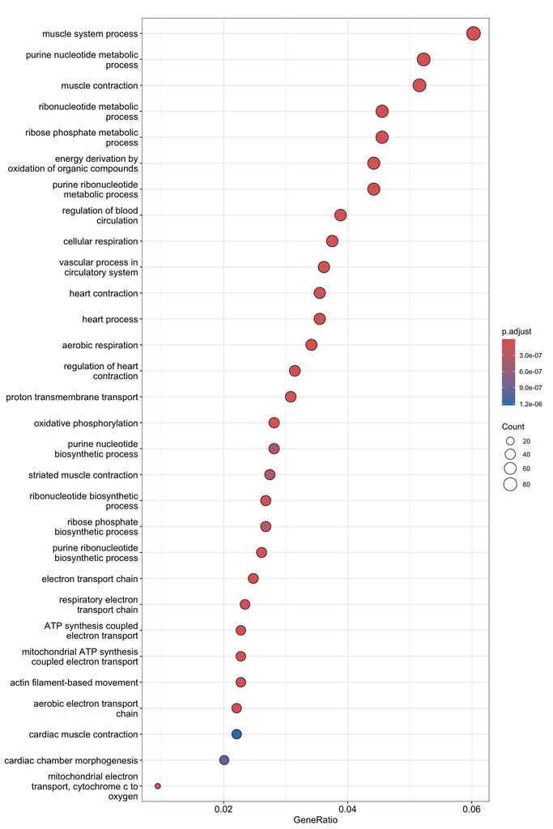

```r
## adjust table
markerG <- markerGenesAllFbExpDH_clusterCond %>%
  filter(avg_log2FC > 0.5) %>%
  filter(cluster %in% c("donorheart_PerivFb2")) %>%
  mutate(Gene = sub("^.*\\.", "", gene),
         EnsID = sub("\\..*", "", gene))

## GSEA
ego <- enrichGO(gene = unique(markerG$EnsID),
                          OrgDb = "org.Hs.eg.db",
                          keyType = 'ENSEMBL',
                          ont = "BP",
                          pAdjustMethod = "BH",
                          pvalueCutoff = 0.05,
                          qvalueCutoff = 0.05)
ego <- setReadable(ego, OrgDb = org.Hs.eg.db)
dotplot(ego, showCategory=30)
```